# 1.6 读、写数据文件

授课教师: 李哲源，河南大学数学与统计学院

最后修改日期: 2023-03-05

R软件： 初学**R**语言可以不用安装该软件，不妨试试在线版本：https://rdrr.io/snippets/。

R程序文件：创建一个后缀名为”.R”的文件，比如”example.R”，然后用普通的记事本（notepad）打开。或者，安装一个更高级的记事本（[notepad++](https://github.com/notepad-plus-plus/notepad-plus-plus/releases/latest)）以获得更好的编程体验。

外部数据：本节所需的外部数据可从https://github.com/ZheyuanLi/statistical-modeling-with-R/tree/main/data/chap1获取。

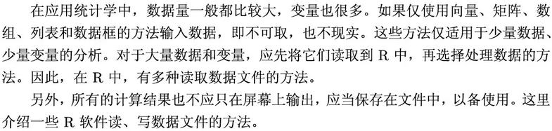

# 1.6.1 读纯文本文件

## 1.6.1-1 `read.table`函数

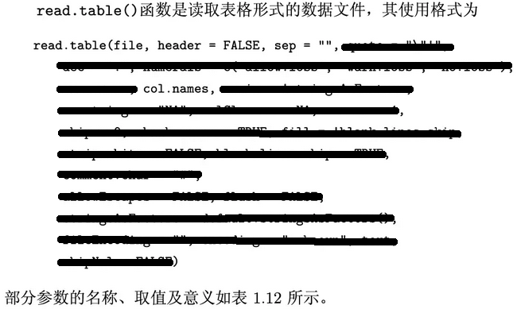

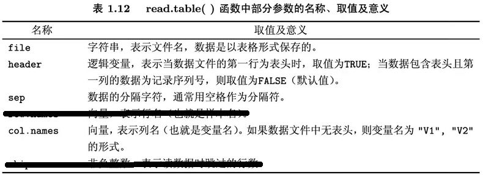

例1：有表头，有行名。

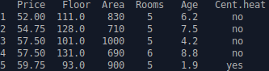

```r
d1 <- read.table("houses1.txt")
d1
```

```
##   Price Floor Area Rooms Age Cent.heat
## 1 52.00   111  830     5 6.2        no
## 2 54.75   128  710     5 7.5        no
## 3 57.50   101 1000     5 4.2        no
## 4 57.50   131  690     6 8.8        no
## 5 59.75    93  900     5 1.9       yes
```

例2：有表头，无行名。

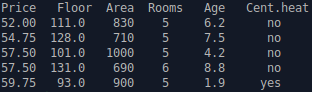

```r
d2 <- read.table("houses2.txt", header = TRUE)
d2
```

```
##   Price Floor Area Rooms Age Cent.heat
## 1 52.00   111  830     5 6.2        no
## 2 54.75   128  710     5 7.5        no
## 3 57.50   101 1000     5 4.2        no
## 4 57.50   131  690     6 8.8        no
## 5 59.75    93  900     5 1.9       yes
```

例3：无表头，无行名。

```r
d3 <- read.table("houses3.txt", header = FALSE,
                 col.names = c("Price", "FLoor", "Area", "Rooms", "Age", "Cent.heat"))
d3
```

```
##   Price FLoor Area Rooms Age Cent.heat
## 1 52.00   111  830     5 6.2        no
## 2 54.75   128  710     5 7.5        no
## 3 57.50   101 1000     5 4.2        no
## 4 57.50   131  690     6 8.8        no
## 5 59.75    93  900     5 1.9       yes
```

例4：无表头，有行名。

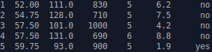

```r
d4 <- read.table("houses4.txt", header = FALSE,
                 col.names = c("ID", "Price", "FLoor", "Area", "Rooms", "Age", "Cent.heat"))
d4
```

```
##   ID Price FLoor Area Rooms Age Cent.heat
## 1  1 52.00   111  830     5 6.2        no
## 2  2 54.75   128  710     5 7.5        no
## 3  3 57.50   101 1000     5 4.2        no
## 4  4 57.50   131  690     6 8.8        no
## 5  5 59.75    93  900     5 1.9       yes
```

```r
d4 <- d4[-1]
d4
```

```
##   Price FLoor Area Rooms Age Cent.heat
## 1 52.00   111  830     5 6.2        no
## 2 54.75   128  710     5 7.5        no
## 3 57.50   101 1000     5 4.2        no
## 4 57.50   131  690     6 8.8        no
## 5 59.75    93  900     5 1.9       yes
```

## 1.6.1-2 `scan`函数

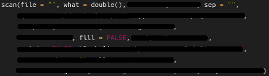

参数解读：

- `file`指明的文件可以包括很多行，`scan`将逐行扫描;
- `sep`指的是用于分割行内数据的分隔符；
- `what`指明数据类型：
  - 如果是单一类型，如实值、复值、逻辑值、字符串，则`scan`返回该类型的向量（见例1，2，3）；
  - 如果是用`list`指明的多种类型，则`scan`执行交替读取（需配套使用参数`fill = TRUE`），返回一个列表（见例4，5）。

例1：空白分隔，全部读入一个向量。

```r
v1 <- scan("weight1.txt", what = 0)
v1
```

```
##  [1] 75.0 64.0 47.4 66.9 62.2 62.2 58.7 63.5 66.6 64.0 57.0 69.0 56.9 50.0 72.0
```

例2：逗号（英文格式）分隔，全部读入一个向量。

```r
v2 <- scan("weight2.txt", what = 0, sep = ",")
v2
```

```
##  [1] 75.0 64.0 47.4 66.9 62.2 62.2 58.7 63.5 66.6 64.0 57.0 69.0 56.9 50.0 72.0
```

例3：补充例2，注意理解行末逗号（可以不止一个哦）的含义。

```r
v3 <- scan("weight3.txt", what = 0, sep = ",")
v3
```

```
##  [1] 75.0 64.0 47.4 66.9 62.2 62.2 58.7 63.5   NA 66.6 64.0 57.0 69.0 56.9 50.0
## [16] 72.0
```

例4：交替读取，返回多个向量后并入一个列表。

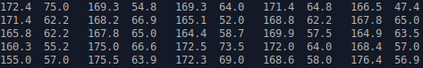

```r
l1 <- scan("h&w1.txt", what = list(height = 0, weight = 0))
l1
```

```
## $height
##  [1] 172.4 169.3 169.3 171.4 166.5 171.4 168.2 165.1 168.8 167.8 165.8 167.8
## [13] 164.4 169.9 164.9 160.3 175.0 172.5 172.0 168.4 155.0 175.5 172.3 168.6
## [25] 176.4
##
## $weight
##  [1] 75.0 54.8 64.0 64.8 47.4 62.2 66.9 52.0 62.2 65.0 62.2 65.0 58.7 57.5 63.5
## [16] 55.2 66.6 73.5 64.0 57.0 57.0 63.9 69.0 58.0 56.9
```

例5：补充例4，理解为什么要使用`fill = TRUE`。

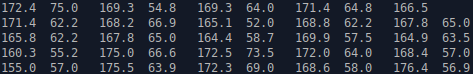

```r
l2 <- scan("h&w2.txt", what = list(height = 0, weight = 0), fill = TRUE)
l2
```

```
## $height
##  [1] 172.4 169.3 169.3 171.4 166.5 171.4 168.2 165.1 168.8 167.8 165.8 167.8
## [13] 164.4 169.9 164.9 160.3 175.0 172.5 172.0 168.4 155.0 175.5 172.3 168.6
## [25] 176.4
##
## $weight
##  [1] 75.0 54.8 64.0 64.8   NA 62.2 66.9 52.0 62.2 65.0 62.2 65.0 58.7 57.5 63.5
## [16] 55.2 66.6 73.5 64.0 57.0 57.0 63.9 69.0 58.0 56.9
```

```r
## 如果不使用fill = TRUE，就会发生错位
scan("h&w2.txt", what = list(height = 0, weight = 0))
```

```
## $height
##  [1] 172.4 169.3 169.3 171.4 166.5  62.2  66.9  52.0  62.2  65.0  62.2  65.0
## [13]  58.7  57.5  63.5  55.2  66.6  73.5  64.0  57.0  57.0  63.9  69.0  58.0
## [25]  56.9
##
## $weight
##  [1]  75.0  54.8  64.0  64.8 171.4 168.2 165.1 168.8 167.8 165.8 167.8 164.4
## [13] 169.9 164.9 160.3 175.0 172.5 172.0 168.4 155.0 175.5 172.3 168.6 176.4
## [25]    NA
```

# 1.6.2 读取csv格式的表格数据

`read.csv()`是`read.table(, sep = ",")`的“快捷方式”。

注意，“.csv”文件仍然是纯文本文件（即可以用记事本打开）。尽管它可以用Excel打开，但它并不是标准的、后缀名为”xls”、“xlsx”的Excel文件。

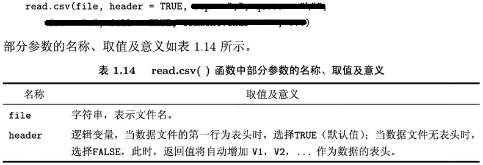

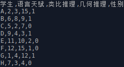

```r
d <- read.csv("scores.csv")
d
```

```
##   学生 语言天赋 类比推理 几何推理 性别
## 1    A        2        3       15    1
## 2    B        6        8        9    1
## 3    C        5        2        7    0
## 4    D        9        4        3    1
## 5    E       11       10        2    0
## 6    F       12       15        1    0
## 7    G        1        4       12    1
## 8    H        7        3        4    0
```

# 1.6.3 读取Excel表格文件

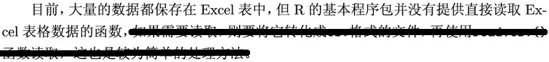

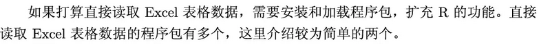

## 1.6.3-1 使用openxlsx程序包

请先自行使用`install.packages("openxlsx")`安装该包。

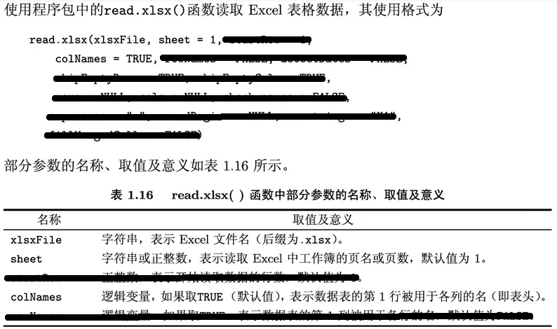

```r
library(openxlsx)
read.xlsx("scores.xlsx")
```

```
##   学生 语言天赋 类比推理 几何推理 性别
## 1    A        2        3       15    1
## 2    B        6        8        9    1
## 3    C        5        2        7    0
## 4    D        9        4        3    1
## 5    E       11       10        2    0
## 6    F       12       15        1    0
## 7    G        1        4       12    1
## 8    H        7        3        4    0
```

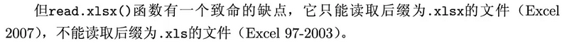

## 1.6.3-2 使用readxl程序包

请先自行使用`install.packages("readxl")`安装该包。

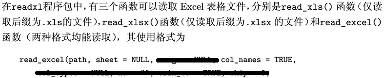

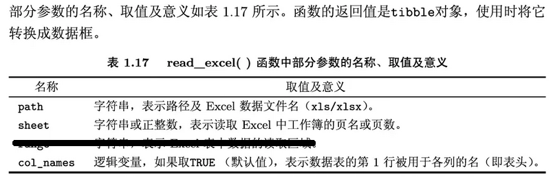

```r
library(readxl)
tb <- read_excel("scores.xlsx")
as.data.frame(tb)
```

```
##   学生 语言天赋 类比推理 几何推理 性别
## 1    A        2        3       15    1
## 2    B        6        8        9    1
## 3    C        5        2        7    0
## 4    D        9        4        3    1
## 5    E       11       10        2    0
## 6    F       12       15        1    0
## 7    G        1        4       12    1
## 8    H        7        3        4    0
```

# 1.6.4 读取R包中的内置数据集

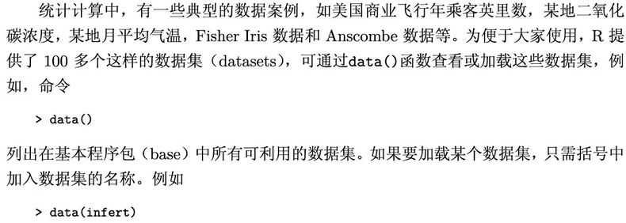

```r
data(infert)

str(infert)
```

```
## 'data.frame':    248 obs. of  8 variables:
##  $ education     : Factor w/ 3 levels "0-5yrs","6-11yrs",..: 1 1 1 1 2 2 2 2 2 2 ...
##  $ age           : num  26 42 39 34 35 36 23 32 21 28 ...
##  $ parity        : num  6 1 6 4 3 4 1 2 1 2 ...
##  $ induced       : num  1 1 2 2 1 2 0 0 0 0 ...
##  $ case          : num  1 1 1 1 1 1 1 1 1 1 ...
##  $ spontaneous   : num  2 0 0 0 1 1 0 0 1 0 ...
##  $ stratum       : int  1 2 3 4 5 6 7 8 9 10 ...
##  $ pooled.stratum: num  3 1 4 2 32 36 6 22 5 19 ...
```

```r
## 查看数据框的前几行
head(infert)
```

```
##   education age parity induced case spontaneous stratum pooled.stratum
## 1    0-5yrs  26      6       1    1           2       1              3
## 2    0-5yrs  42      1       1    1           0       2              1
## 3    0-5yrs  39      6       2    1           0       3              4
## 4    0-5yrs  34      4       2    1           0       4              2
## 5   6-11yrs  35      3       1    1           1       5             32
## 6   6-11yrs  36      4       2    1           1       6             36
```

```r
## 查看数据框的后几行
tail(infert)
```

```
##     education age parity induced case spontaneous stratum pooled.stratum
## 243   12+ yrs  25      1       0    0           1      78             41
## 244   12+ yrs  31      1       0    0           1      79             45
## 245   12+ yrs  34      1       0    0           0      80             47
## 246   12+ yrs  35      2       2    0           0      81             54
## 247   12+ yrs  29      1       0    0           1      82             43
## 248   12+ yrs  23      1       0    0           1      83             40
```

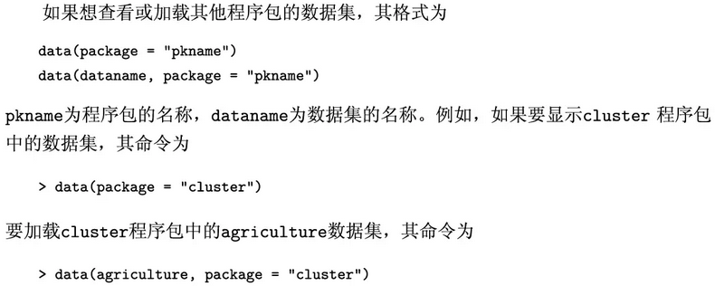

```r
data(package = "cluster")
```

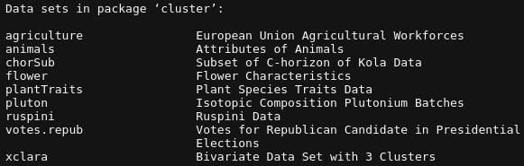

```r
data(agriculture, package = "cluster")

agriculture
```

```
##        x    y
## B   16.8  2.7
## DK  21.3  5.7
## D   18.7  3.5
## GR   5.9 22.2
## E   11.4 10.9
## F   17.8  6.0
## IRL 10.9 14.0
## I   16.6  8.5
## L   21.0  3.5
## NL  16.4  4.3
## P    7.8 17.4
## UK  14.0  2.3
```

# 1.6.5 写数据文件

## 1.6.5-1 `write`函数

与`scan`函数相对应的，是`write`函数。

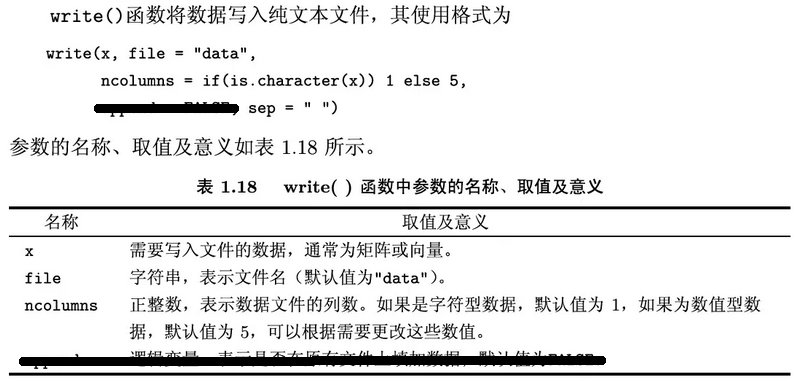

`write`函数可以将一个向量写入文件，输出的文件可以用`scan`读取。

```r
x <- 1:20

write(x, file = "x.txt", ncolumns = 10)
```

```r
write(x, file = "x.csv", ncolumns = 10, sep = ",")
```

`write`也可以将一个矩阵（按列拉成向量）写入文件，输出的文件可以用`scan`读取。

```r
m <- matrix(1:12, nrow = 2); m
```

```
##      [,1] [,2] [,3] [,4] [,5] [,6]
## [1,]    1    3    5    7    9   11
## [2,]    2    4    6    8   10   12
```

```r
write(m, file = "m.txt", ncolumns = 6)
```

将文件读入得到这个矩阵，可使用：

```r
matrix(scan("m.txt", what = 0), ncol = 6)
```

```
##      [,1] [,2] [,3] [,4] [,5] [,6]
## [1,]    1    3    5    7    9   11
## [2,]    2    4    6    8   10   12
```

如果希望将一个矩阵“形式化”地写入文件，则需要先对矩阵转置。

```r
write(t(m), file = "m.txt", ncolumns = 6)
```

但再将该文件读入恢复这个矩阵，注意使用：

```r
## 给matrix函数设置byrow = TRUE
matrix(scan("m.txt", what = 0), ncol = 6, byrow = TRUE)
```

```
##      [,1] [,2] [,3] [,4] [,5] [,6]
## [1,]    1    3    5    7    9   11
## [2,]    2    4    6    8   10   12
```

## 1.6.5-2 `write.table`和`write.csv`函数

与`read`.table`和`read.csv`函数`相对应的，是`write.table`函数（请无视`write.csv`函数）。

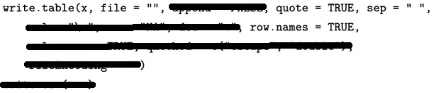

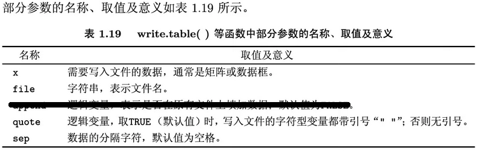

```r
df <- data.frame(Name = c("Alice", "Becka", "James", "Jeffrey", "John"),
                 Sex = c("F", "F", "M", "M", "M"),
                 Age = c(13, 13, 12, 13, 12),
                 Height = c(56.5, 65.3, 57.3, 62.5, 59.0),
                 Weight = c(84.0, 98.0, 83.0, 84.0, 99.5))
df
```

```
##      Name Sex Age Height Weight
## 1   Alice   F  13   56.5   84.0
## 2   Becka   F  13   65.3   98.0
## 3   James   M  12   57.3   83.0
## 4 Jeffrey   M  13   62.5   84.0
## 5    John   M  12   59.0   99.5
```

```r
write.table(df, file = "df.txt")
```

```r
write.table(df, file = "df.txt", quote = FALSE)
```

```r
write.table(df, file = "df.txt", quote = FALSE, row.names = FALSE)
```

```r
write.table(df, file = "df.csv", sep = ",")
```

```r
write.table(df, file = "df.csv", sep = ",", quote = FALSE)
```

```r
write.table(df, file = "df.csv", sep = ",", quote = FALSE, row.names = FALSE)
```

## 1.6.5-3 `write.xlsx`函数

`write.xlsx`函数是**openxlsx**程序包中的函数，它的作用是将数据写入Excel表格（Excel 2007）中，其使用格式为

```r
write.xlsx(x, file)
```

```r
library(openxlsx)

write.xlsx(df, file = "df.xlsx")
```

# 作业

1. [不提交] 在上机课上运行本课所有代码；
2. [提交] 课本56页，第17、22、23题。